# Laboratorio 11-MD

Leislie R. Manjarrez O.

2023-02-22

Laboratorio 11: Vision clara del espacio-producto: CASO REAL_exportaciones hidalguenses

Objetivo: Estimar el Maximum Spanning Tree -arbol de expansion maxima- (asegurar una vision clara del espacio-producto) Red troncal: Estructura general de la red: vamos a poder ver redes complejas

Regla 1: Mantener n-1 conexiones como maximo Regla 2: Quitar las conexiones con el peso mas bajo, nos vamos quedar con las del peso maximo (menos conexiones) Regla 3: No crear nodos aislados

1.Como crear una vision clara del espacio-producto: arbol de expansion maxima (MST) Paquete: Balland, P.A. (2017) Economic Geography in R: Introduction to the EconGeo Package, Papers in Evolutionary Economic Geography, 17 (09): 1-75 Para instalar: https://www.paballand.com/install-r

Cargar libreria de EconGeo

```r
library(EconGeo)
```

Ubicar archivo a utilizar, al ejecutar señala la ruta la cual debe ser copiada y pegada despues de read.csv

```r
file.choose()
```

```
## [1] "C:\\Users\\leisl\\OneDrive\\Doctorado\\Semestre-3\\Temas-Selectos-1-Complejidad-Económica\\Modulo2\\Semana4-Labs-Salas\\Lab-11\\relatednessbinario.csv"
```

```r
M = as.matrix(
  read.csv("relatednessbinario.csv",
           sep = ",",
           header = T,
           row.names = 1))
```

Comandos para visualizar una parte de la matriz compleja cargada con anterioridad

```r
head (M[,1:10])
```

```
##      X102 X210 X401 X403 X406 X510 X602 X603 X702 X703
## X102    0    0    1    1    0    0    0    0    0    0
## X210    0    0    0    1    1    0    0    0    1    0
## X401    1    0    0    0    0    0    0    0    0    0
## X403    1    1    0    0    1    0    0    0    0    0
## X406    0    1    0    1    0    0    0    0    1    0
## X510    0    0    0    0    0    0    0    0    0    0
```

```r
dim (M)
```

```
## [1] 429 429
```

Realizar un primer grafico de la matriz, cargar libreria para ello

```r
library (igraph)
```

Comandos para generar grafico denominado red_hidalgo1

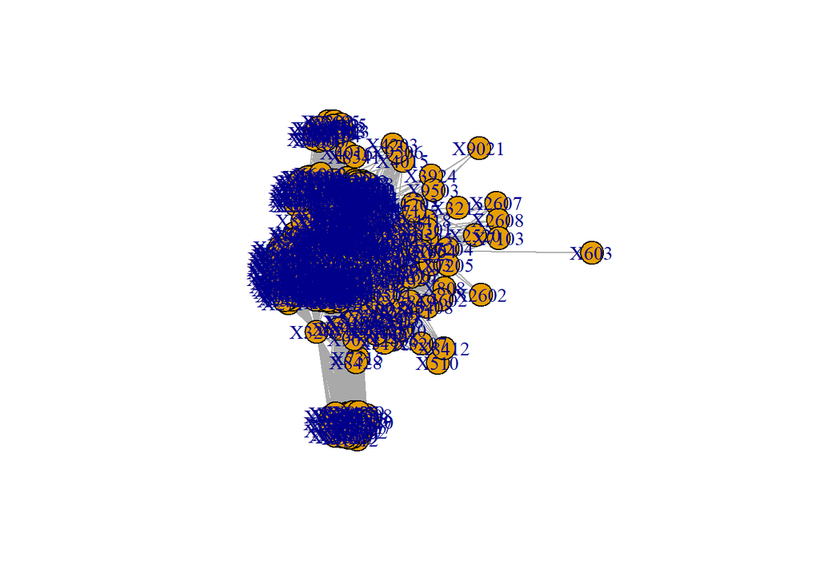

```r
red_hidalgo1 <-graph.adjacency(M, mode="undirected", weighted=TRUE)
plot(red_hidalgo1)
```

Modificamos la matriz original a una matriz negativa

```r
M <- -M
head (M[,1:6])
```

```
##      X102 X210 X401 X403 X406 X510
## X102    0    0   -1   -1    0    0
## X210    0    0    0   -1   -1    0
## X401   -1    0    0    0    0    0
## X403   -1   -1    0    0   -1    0
## X406    0   -1    0   -1    0    0
## X510    0    0    0    0    0    0
```

Graficamos la matriz negativa, grafica de adyacencias con un input la matriz invertida a la que se le calcula el MST

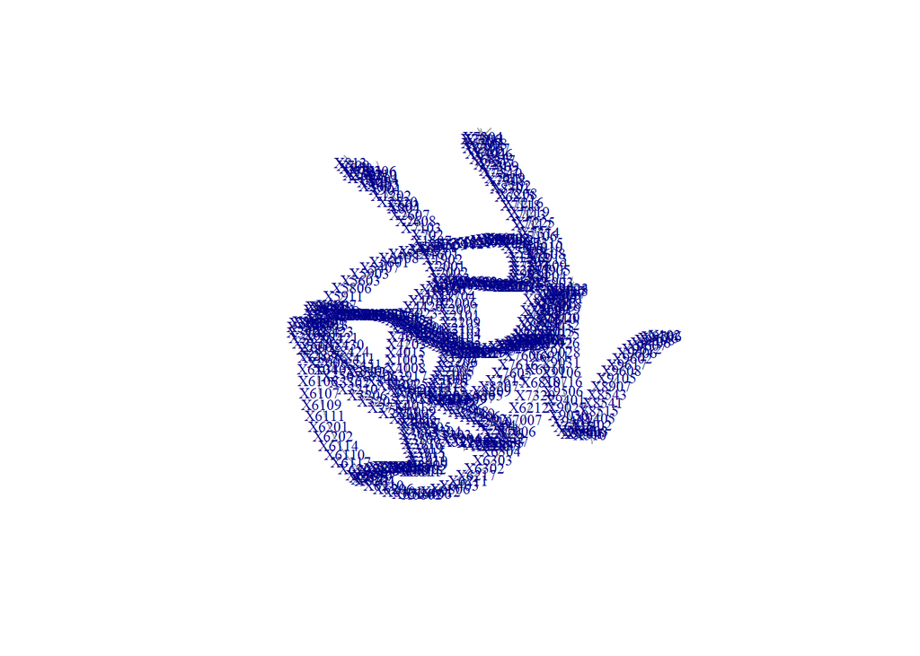

```r
red_hidalgo2 <-graph.adjacency(M, mode="undirected", weighted=TRUE)
MST <- minimum.spanning.tree(red_hidalgo2)
plot (MST, vertex.shape= "none", vertex.label.cex=.7)
```

Exportar los datos del grafico limpio

```r
write.graph(MST, file = "redhidalgo2.gml", format = "gml")
```

Generar matriz de adyacencias

```r
A <- get.adjacency(MST, sparse = F)
```

Exportar la matriz de adyacencias creada

```r
write.csv(A, file = "AdyacentesConMST.csv")
```